# Customer Analysis

Nguyen Pham

April 28, 2022

# An Introduction

- Understanding the importance of customer behaviors.
- By measuring their behavior, we can analyze which customer segment that should focus on, or market the product to the particular segment.
- The purpose of choosing this data because I want to find some information that I do not know such as the difference of purchases base on customer’s age, income, or marital status.

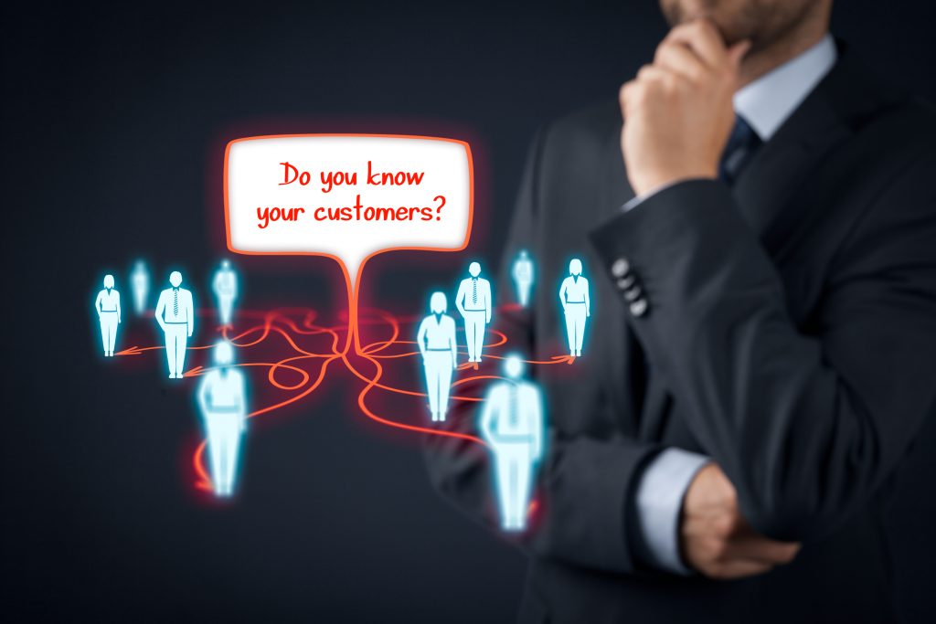

# Packages Require

```r
library(scales)
library(knitr)           # for html publication
library(tidyverse)       # for data tidying
```

```r
library(dplyr)           # for data manipulation
library(ggplot2)         # for data visualization
library(scales)
options(scipen = 999)
options(repos=structure(c(CRAN="https:theclosest_mirror_to_yourlocation.com")))
```

# Import Data

- My data set is from [Kaggle]: (https://www.kaggle.com/datasets/imakash3011/customer-personality-analysis). This data from the kaggle public datasets. It was collected by Akash Patel and its target to perform clustering to summarize customer segments. The dataset for this project is provided by Dr.Omar Romero-Hernandez.

To ensure the data is clean and clear, I will check for any missing data and removed all the missing data to ready to be used for analysis.

```
## [1] 24
```

```
## [1] 0
```

Now the data is clean and all missing data is removed, so let take a loot at the data and change some variable names to make sure the reader can understand. This data has 29 columns, and 2216 rows.

```
## Rows: 2,216
## Columns: 29
## $ ID                  <int> 5524, 2174, 4141, 6182, 5324, 7446, 965, 6177, 485~
## $ Year_Birth          <int> 1957, 1954, 1965, 1984, 1981, 1967, 1971, 1985, 19~
## $ Education           <chr> "Graduation", "Graduation", "Graduation", "Graduat~
## $ Marital_Status      <chr> "Single", "Single", "Together", "Together", "Marri~
## $ Income              <int> 58138, 46344, 71613, 26646, 58293, 62513, 55635, 3~
## $ Kidhome             <int> 0, 1, 0, 1, 1, 0, 0, 1, 1, 1, 0, 0, 1, 0, 0, 1, 0,~
## $ Teenhome            <int> 0, 1, 0, 0, 0, 1, 1, 0, 0, 1, 0, 0, 1, 0, 0, 1, 0,~
## $ Dt_Customer         <chr> "04-09-2012", "08-03-2014", "21-08-2013", "10-02-2~
## $ Recency             <int> 58, 38, 26, 26, 94, 16, 34, 32, 19, 68, 59, 82, 53~
## $ MntWines            <int> 635, 11, 426, 11, 173, 520, 235, 76, 14, 28, 6, 19~
## $ MntFruits           <int> 88, 1, 49, 4, 43, 42, 65, 10, 0, 0, 16, 61, 2, 14,~
## $ MntMeatProducts     <int> 546, 6, 127, 20, 118, 98, 164, 56, 24, 6, 11, 480,~
## $ MntFishProducts     <int> 172, 2, 111, 10, 46, 0, 50, 3, 3, 1, 11, 225, 3, 6~
```

[output cut: 16 more lines]

Because the data has many information and different values, I will check for duplicated values and removed it before analysis.

```
## [1] 0
```

# Data preparation

- Next step, I will mutate some column that I need to analyse and use in the future.
- In the data, there are some strange names and some variables very similar, I will change theirs names and make the data clean and clear to read.

# Data Visualzation

- For me the data is messy to read and there are a lot of different numbers. Therefor, I will graph and visualization the information of age, spend, income, and children,by graph the information to make clear and easier to see.

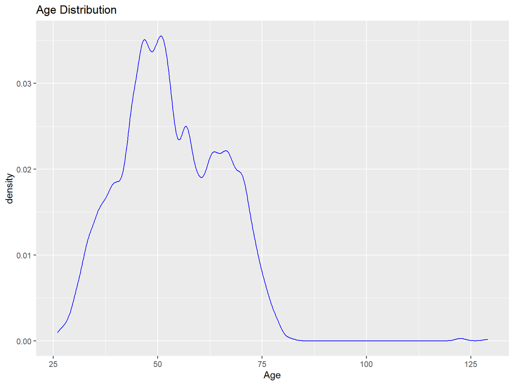

# Income distribution

- There is an value that larger than the others values, so I will filter the variable to make the graph look better.

```
##   max(Income)
## 1      666666
```

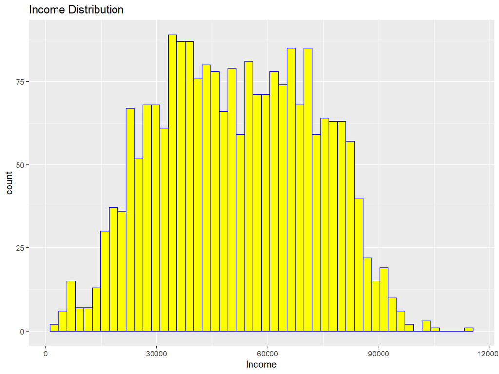

# Spend distribution

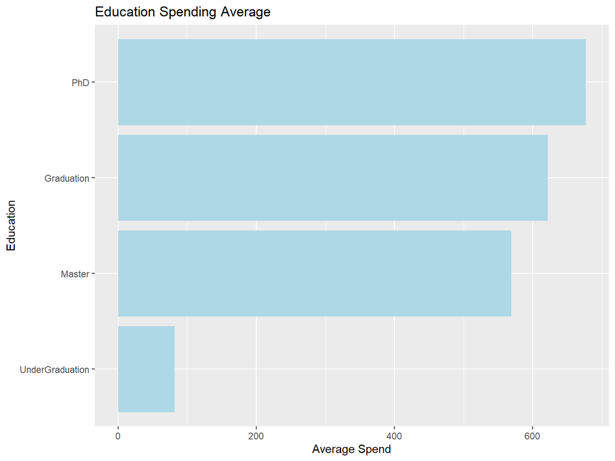

# Number of children

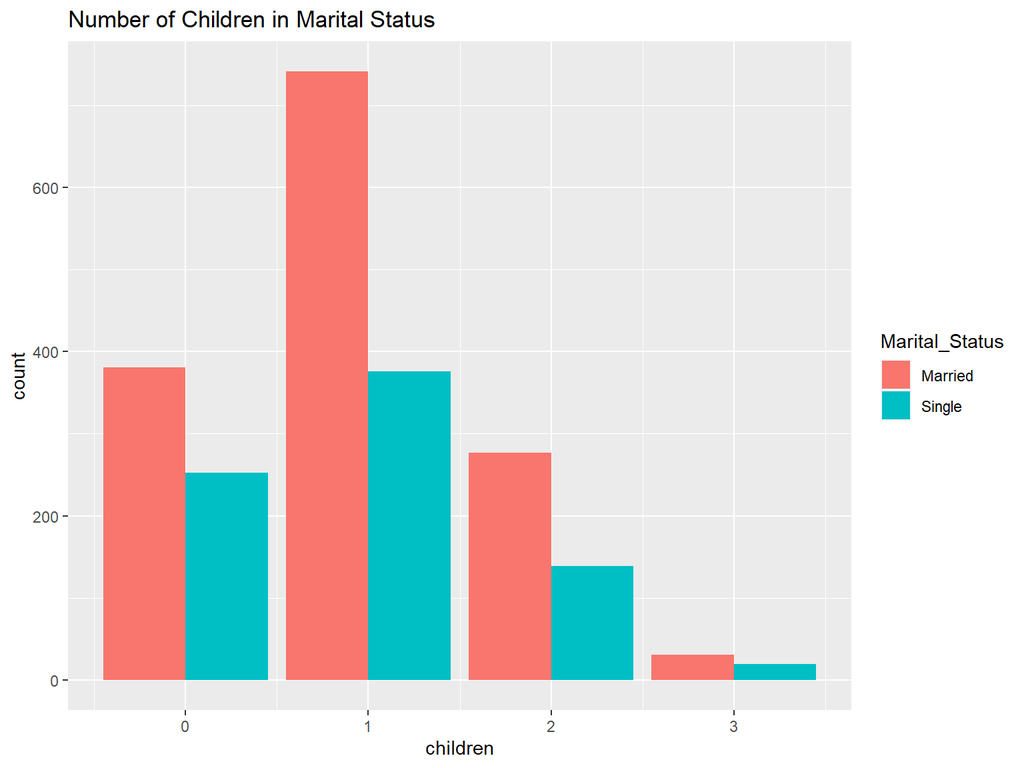

# Data Exploration

** Income vs spend**

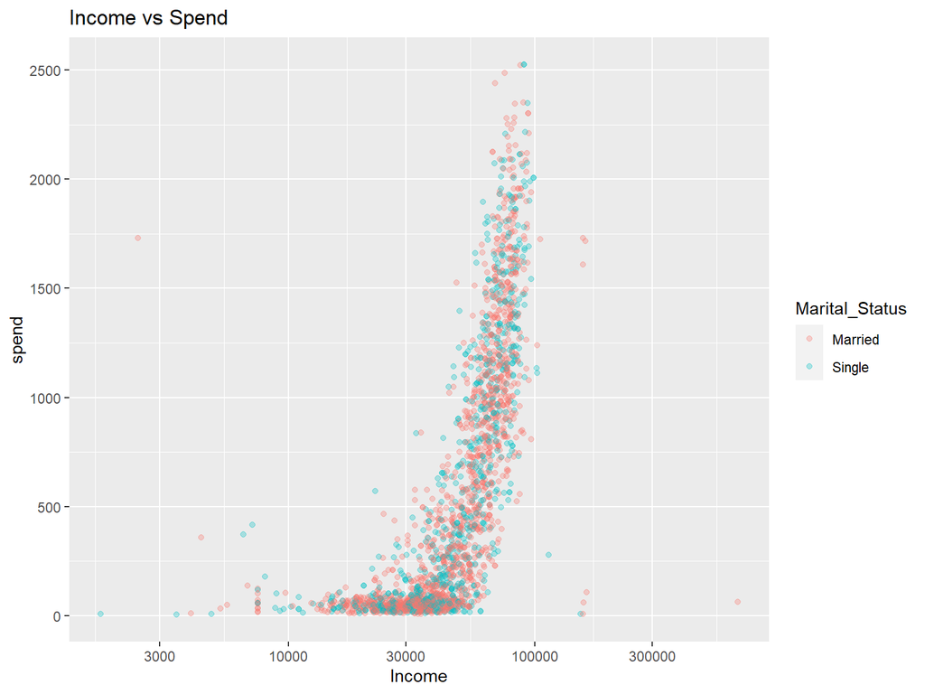

# Income level and spending on different kind of products.

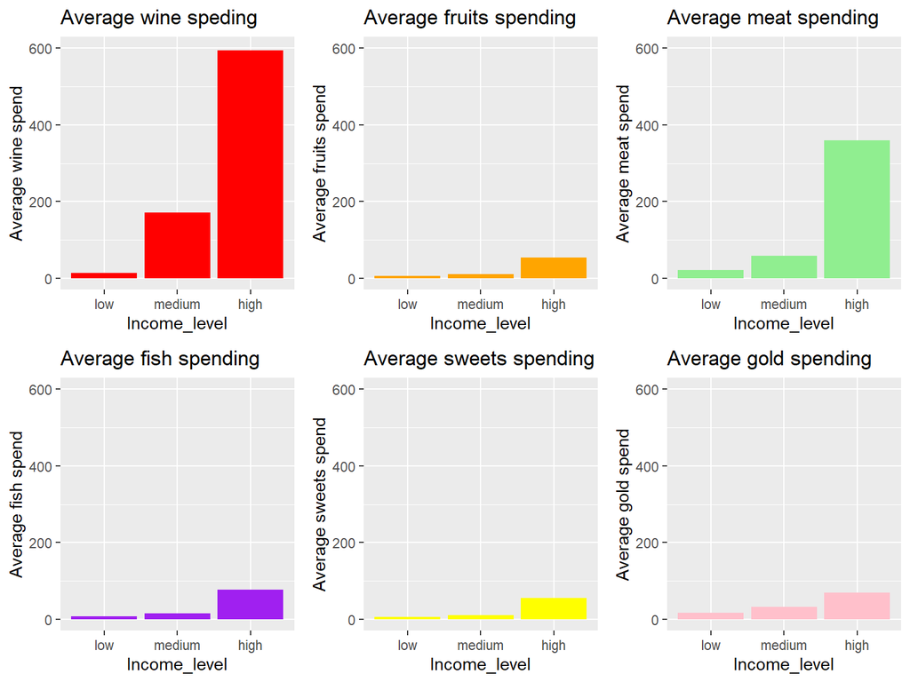

# What kind of products do people spend the most by income level and children?

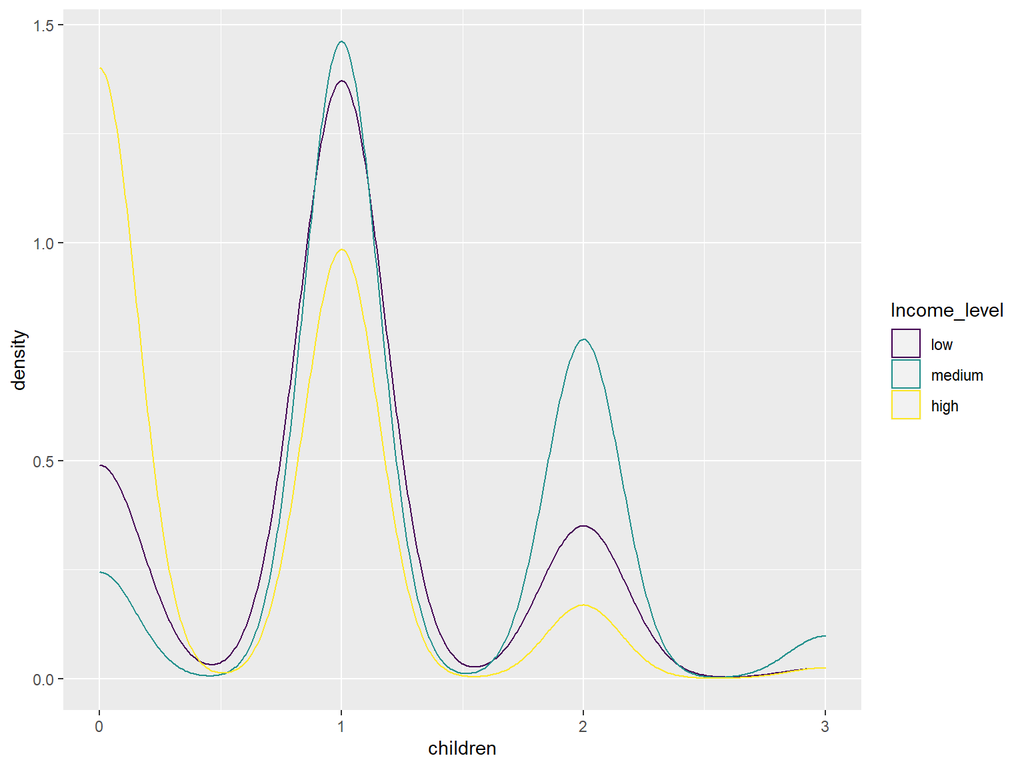

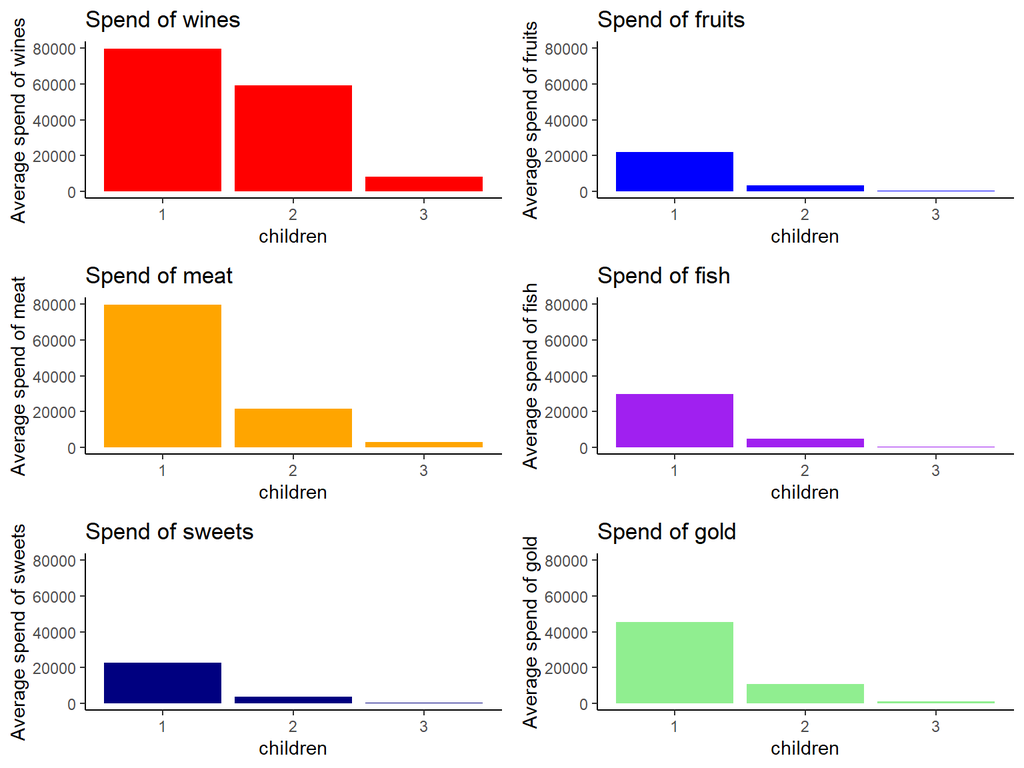

# Which group of different income who have children spend more on sweets products?

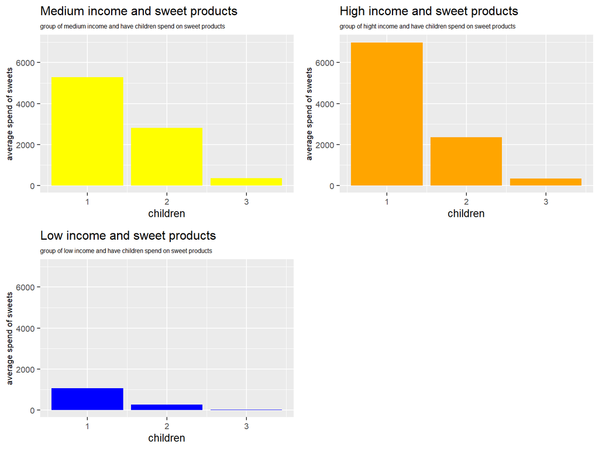

# Income vs promotion

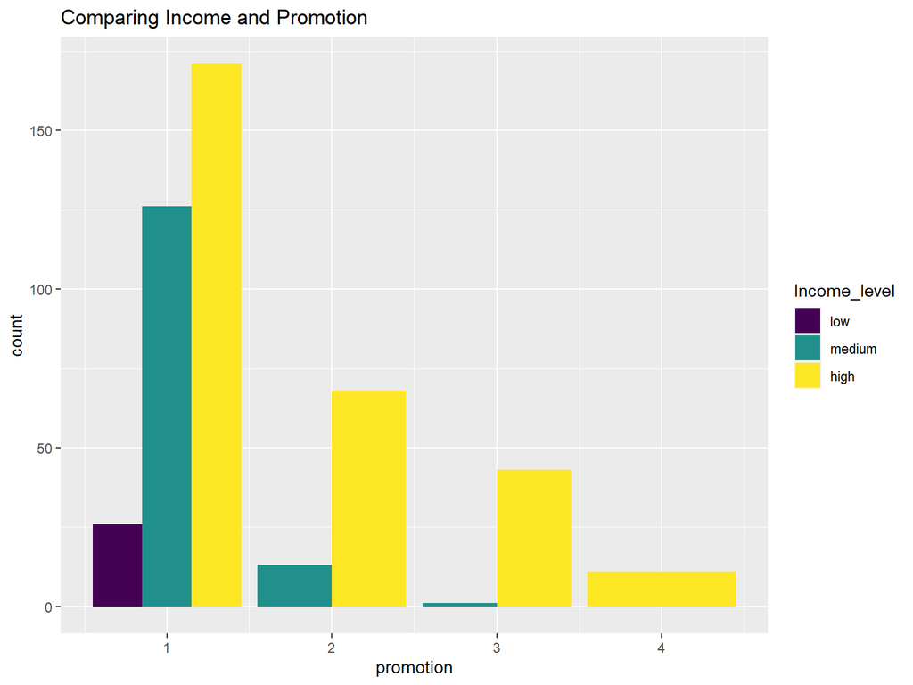

- After looking the information base on income, I also want to see what if anything change base on the ages. Therefore, next step I will do some more data analyse such as mutate new column, make statement or argument to separate the group of age to find more information to answer my concern.

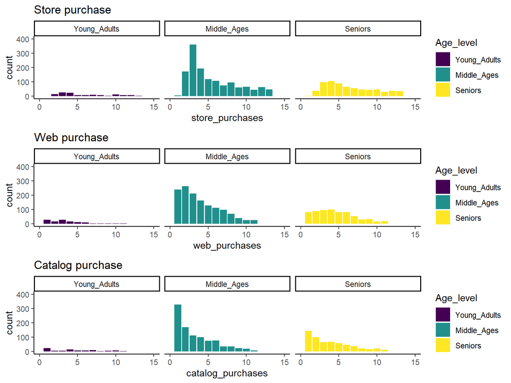

## Percentage of Purchases

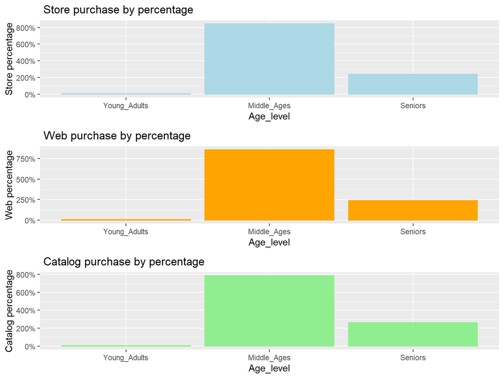

# Age and spending by different type of products

What kind of products people like more than others by their ages?

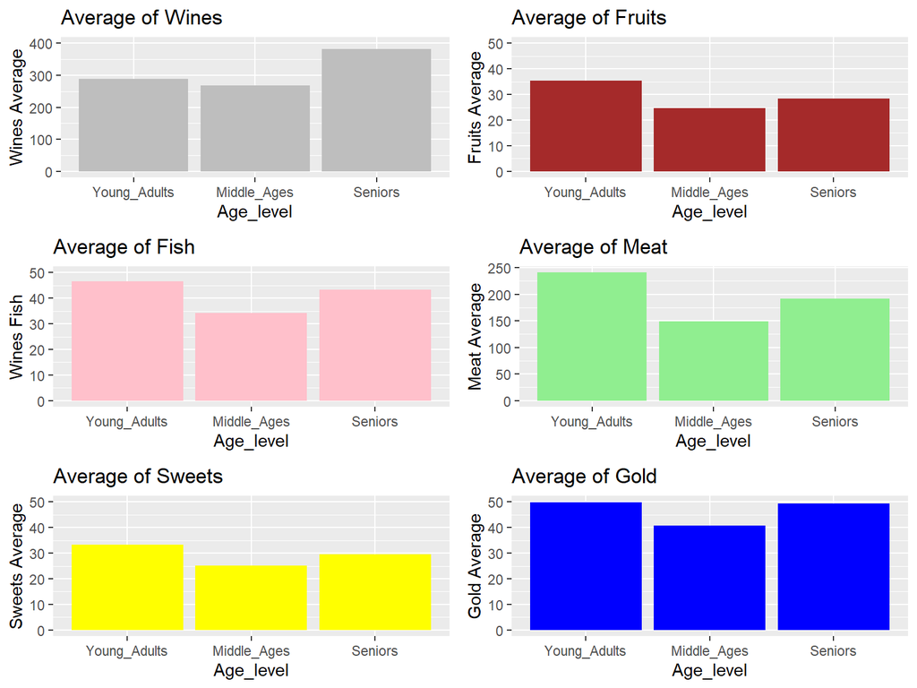

# Summary